# A Statistical Analysis of Happiness and Life Expectancy

Wentao Li, Hongyan Zheng

7/5/2021

The decade of The Tens marked a period of great international migration and travel. Whether it was in the cabin of international flights, the deck of a cruise ship, or the backseat of a minivan, travelling, adventuring and migrating defined the decade as people seek a better life for their family and children. According to the United Nations, by the end of the decade, the number of international migrant reached 272 million, with Europe and North America receiving the majority. The pursuit of material success often mirrored a pursuit of a happy, long-lasting life. This was reflected in the recent World Happiness Reports, in which Nordic countries often topped the charts in their happiness rank, the Life Ladder Rank. Therefore we conceded ourselves to the following main questions that has inquired millenniums of philosophy and religion: “Is there a possible way to maximize human life expectancy? Is happiness the key?” In the below study, we hope to examine the various socio-economic variables that would affect both happiness and life expectancy, how geography impacts happiness and life expectancy, and whether having a high life expectancy had any relations to having a happy life, and vice versa. To analyze these possible relationships, we have asked ourselves the following questions: “Does a change in life expectancy reflect a similar change in happiness, vise versa?”, “Are these socio-economic variables provided by the World Happiness Report related to life expectancy?”, “Which variable affects life expectancy and happiness the most?”, “Does geography have an impact on life expectation and happiness?”.

To answer these relationship and questions, we have imported, cleaned and analyzed three datasets, “The World Happiness Report” powered by data from Gallup World Poll, “Global Life Expectancy” collected from ourworldindata.org, and a dataset containing all countries and their respective continents. Both “The World Happiness Report” and “Global Life Expectancy” datasets were filtered such that only statistics from 2008 to 2019 is observed, as it not only contains the full decade from 2010 to 2019, but also 2 years prior to observe the statistics prior to the start of the decade.

To discover the relationship between socio-economic variables and life expectancy, we utilized a linear regression model to analyze our data due to the large amount of numeric values. We were able to discover which values were significant. And through this process, we discovered that in relation to life expectancy, all other variables except “Perception of Corruption” had a significant relationship with life expectancy. Therefore we can conclude from this data that how a person view corruption will most likely not have a significant impact on their life expectancy. To discover the relationship between geography (continents) and life expectancy and subsequently happiness, we mainly utilized the built-in functions of ggplot. We separately plotted “Life Expectancy” and “Happiness” against “Year”, to show the change in life expectancy from 2008 to 2019, and separated the different values for different continents.

Here’s how life expectancy and happiness for each continent has changed over the last decade:

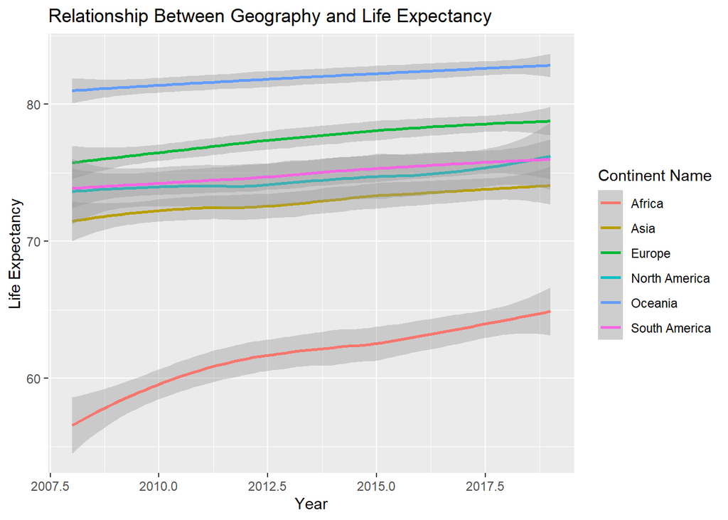

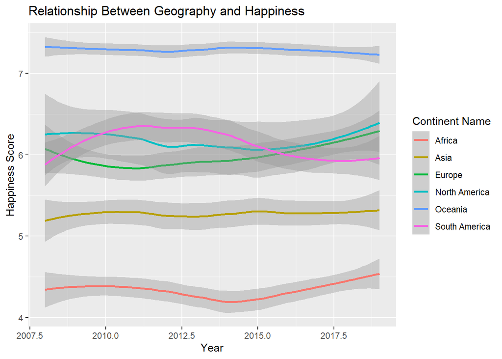

To further analyze the reason behind these changes, we look to discover the relationship between socio-economic variables and life expectancy, we utilized a linear regression model to analyze our data due to the large amount of numeric values. We were able to discover which values were significant. And through this process, we discovered that in relation to life expectancy, all other variables except “Perception of Corruption” had a significant relationship with life expectancy. Therefore we can conclude from this data that how a person view corruption will most likely not have a significant impact on their life expectancy.

In fact, we can explore this further and discover which variable has the most effect on both life expectancy and worldwide happiness. Further utilizing linear models and tidy tools, we were able to discover that for both happiness and life expectancy, the variable that has the most consistently high impact on both life expectancy and worldwide happiness is “Social Support”.

Here is how life expectancy and happiness change in relation to social support:

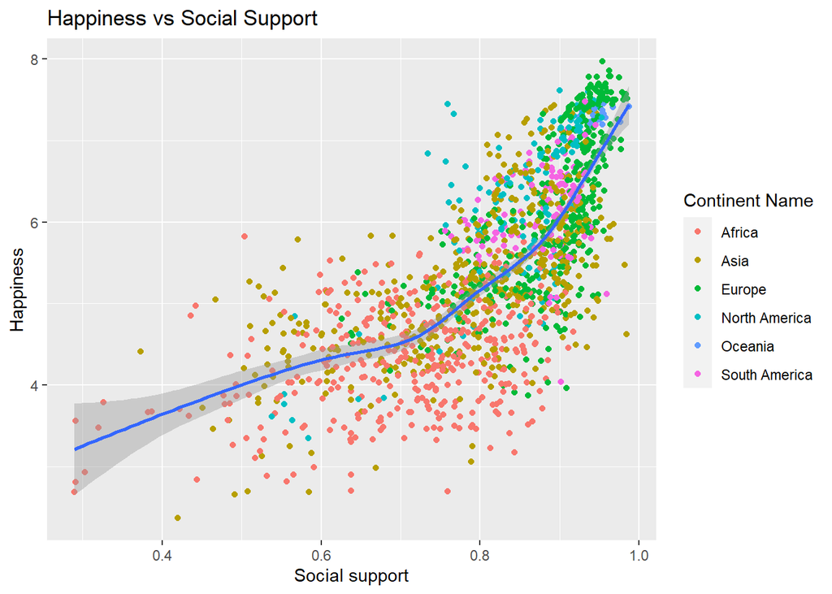

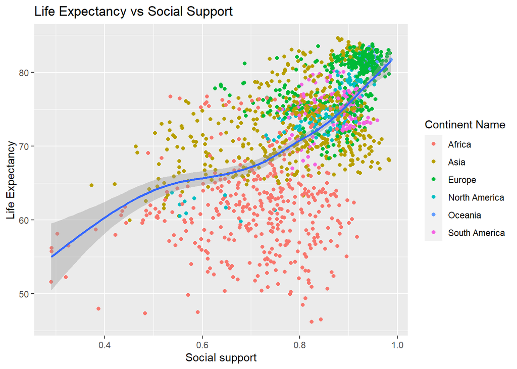

As we can see from the above plot, Social Support has a positive relationship with both life expectancy and happiness. And more importantly, both “Happiness” and “Life Expectancy” follows the previous established relationship with “Geography”.

This allows us to advance to the final question to our discussion. What is the relationship between happiness and life expectancy, vise versa? Are happy people more likely to live longer? And more importantly, if they are related, how does the change in one variable affect the change in another?

To answer this question, we utilized linear regression models and tidy tools to observe and validify both how “Life Expectancy” relates to “Happiness”, and how “Happiness” relates to “Life Expectancy”. The linear model allowed us to observe a significance for both relationships. We are able to conclude that while both relationships are significant, 1 unit increase in happiness meant an increase of 5.5 in life expectancy and 1 unit increase in life expectancy reflected in a 0.0948 increase in happiness.

Here is how Life Expectancy is related to Happiness, the reverse relationship can also be observed:

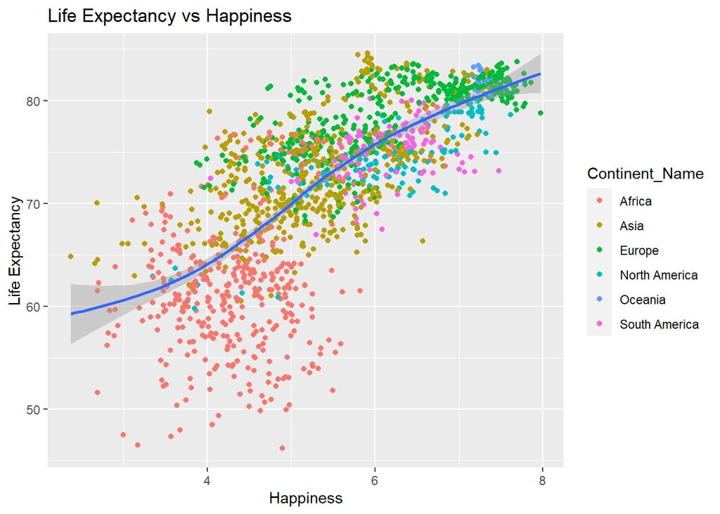